# Fusion des bases welfare des EHCVM 2018 et 2021

DJERAKEI MISTALENGAR

30 mars 2025

Structure générale

Ce script RMarkdown a pour objectif de fusionner deux bases de données (EHCVM 2018 et 2021) sur le bien-être au Sénégal. Il suit une approche méthodique pour harmoniser les structures, les encodages et les labels des variables avant la fusion.

# 1 Gestion des packages

```r
packages <- c("haven", "utils", "dplyr", "tidyverse","labelled", "expss", "sjPlot", "janitor")

for (pkg in packages) {
  if (!require(pkg, character.only = TRUE))
    install.packages(pkg, dependencies = TRUE)
  library(pkg, character.only = TRUE)
}
```

```r
# Supprimer toutes les variables de l'environnement
rm(list = ls())

# Forcer un nettoyage de la mémoire
gc()
```

```
##           used (Mb) gc trigger  (Mb) max used (Mb)
## Ncells 1164201 62.2    2421497 129.4  1466352 78.4
## Vcells 2010064 15.4    8388608  64.0  2843364 21.7
```

# 2 Chargement des Données

```r
# Charger les bases sans conversion immédiate des labels

wel_18 <- read_dta("../Donnees/ehcvm_welfare_sen2018.dta")


wel_21 <- read_dta("../Donnees/ehcvm_welfare_sen2021.dta")
```

```r
glimpse(wel_21)
```

```
## Rows: 7,120
## Columns: 47
## $ grappe               <dbl> 2, 2, 2, 2, 2, 2, 2, 2, 2, 2, 2, 2, 3, 3, 3, 3, 3…
## $ menage               <dbl> 5, 15, 3, 13, 8, 16, 7, 4, 1, 12, 14, 6, 7, 13, 9…
## $ country              <chr> "SEN", "SEN", "SEN", "SEN", "SEN", "SEN", "SEN", …
## $ year                 <dbl> 2021, 2021, 2021, 2021, 2021, 2021, 2021, 2021, 2…
## $ hhid                 <dbl> 205, 215, 203, 213, 208, 216, 207, 204, 201, 212,…
## $ vague                <dbl> 2, 2, 2, 2, 2, 2, 2, 2, 2, 2, 2, 2, 1, 1, 1, 1, 1…
## $ month                <date> 2022-05-01, 2022-05-01, 2022-05-01, 2022-05-01, …
## $ zae                  <dbl+lbl> 11, 11, 11, 11, 11, 11, 11, 11, 11, 11, 11, 1…
## $ region               <dbl+lbl> 1, 1, 1, 1, 1, 1, 1, 1, 1, 1, 1, 1, 1, 1, 1, …
## $ milieu               <dbl+lbl> 1, 1, 1, 1, 1, 1, 1, 1, 1, 1, 1, 1, 1, 1, 1, …
## $ hhweight             <dbl> 386.2073, 386.2073, 386.2073, 386.2073, 290.0678,…
## $ hhsize               <dbl> 3, 2, 3, 5, 1, 5, 1, 3, 9, 6, 4, 3, 1, 2, 5, 5, 2…
## $ eqadu1               <dbl> 2.280, 1.660, 2.820, 4.000, 0.790, 3.830, 0.760, …
```

[output cut: 34 more lines]

```r
glimpse(wel_18)
```

```
## Rows: 7,156
## Columns: 35
## $ country   <chr> "SEN", "SEN", "SEN", "SEN", "SEN", "SEN", "SEN", "SEN", "SEN…
## $ year      <dbl> 2018, 2018, 2018, 2018, 2018, 2018, 2018, 2018, 2018, 2018, …
## $ hhid      <dbl> 1001, 1002, 1003, 2001, 2002, 2003, 2004, 2005, 2006, 2007, …
## $ grappe    <dbl> 1, 1, 1, 2, 2, 2, 2, 2, 2, 2, 2, 2, 2, 2, 2, 3, 3, 3, 3, 3, …
## $ menage    <dbl> 1, 2, 3, 1, 2, 3, 4, 5, 6, 7, 8, 9, 10, 11, 12, 1, 2, 3, 4, …
## $ vague     <dbl> 1, 1, 1, 2, 2, 2, 2, 2, 2, 2, 2, 2, 2, 2, 2, 1, 1, 1, 1, 1, …
## $ zae       <dbl> 1, 1, 1, 1, 1, 1, 1, 1, 1, 1, 1, 1, 1, 1, 1, 1, 1, 1, 1, 1, …
## $ region    <dbl+lbl> 1, 1, 1, 1, 1, 1, 1, 1, 1, 1, 1, 1, 1, 1, 1, 1, 1, 1, 1,…
## $ milieu    <dbl+lbl> 1, 1, 1, 1, 1, 1, 1, 1, 1, 1, 1, 1, 1, 1, 1, 1, 1, 1, 1,…
## $ hhweight  <dbl> 1749.8322, 1749.8322, 1749.8322, 266.3170, 266.3170, 266.317…
## $ hhsize    <dbl> 2, 2, 1, 10, 6, 4, 3, 2, 3, 1, 4, 1, 3, 1, 6, 7, 3, 1, 8, 10…
## $ eqadu1    <dbl> 1.320, 1.450, 1.000, 7.660, 4.280, 3.140, 2.520, 1.420, 2.11…
## $ eqadu2    <dbl> 1.612145, 1.612145, 1.000000, 5.539459, 3.246247, 2.444710, …
```

[output cut: 22 more lines]

Appliquer la conversion à toutes les colonnes de la base 2018. La fonction lapply permet de parcourir chaque colonne et d’appliquer iconv pour ajuster l’encodage.

```r
wel_18[] <- lapply(wel_18, function(x) iconv(x, from = "latin1", to = "UTF-8"))
```

# 3 Diagnostic des Données

Pour un meilleur traitement, nous commençons par analyser et comprendre les deux bases, afin de voir les similitudes et les divergences.

## 3.1 Doublons

Vérification des doublons

Vérifie l’unicité des identifiants de ménage (hhid) dans les deux bases

```r
anyDuplicated(wel_18$hhid)
```

```
## [1] 0
```

```r
anyDuplicated(wel_21$hhid)
```

```
## [1] 0
```

Aucun ménage n’est dupliqué dans les deux bases.

## 3.2 Valeurs Manquantes

Implémente une fonction calc_na_stats() pour calculer: le nombre de NA par variable, le pourcentage de NA par rapport au total.

Affiche les résultats triés par pourcentage décroissant

```r
# Fonction pour calculer les valeurs manquantes et les pourcentages
calc_na_stats <- function(data) {
  na_counts <- colSums(is.na(data))  # Nombre de NA par colonne
  total_rows <- nrow(data)  # Nombre total de lignes
  na_percent <- (na_counts / total_rows) * 100  # Pourcentage de NA

  # Créer un tableau récapitulatif
  na_stats <- data.frame(
    Variable = names(na_counts),
    NA_Count = na_counts,
    NA_Percentage = round(na_percent, 2)  # Arrondi à 2 décimales
  )

  # Trier les résultats par pourcentage décroissant
  na_stats <- na_stats[order(-na_stats$NA_Percentage), ]

  return(na_stats)
}
```

Valeurs manquantes - Base 2018

```r
NA_stats_2018 <- calc_na_stats(wel_18)
print(NA_stats_2018)
```

```
##            Variable NA_Count NA_Percentage
## hbranch     hbranch     1722         24.06
## hsectins   hsectins     1722         24.06
## hcsp           hcsp     1722         24.06
## hmstat       hmstat        2          0.03
## country     country        0          0.00
## year           year        0          0.00
## hhid           hhid        0          0.00
## grappe       grappe        0          0.00
## menage       menage        0          0.00
## vague         vague        0          0.00
## zae             zae        0          0.00
## region       region        0          0.00
## milieu       milieu        0          0.00
## hhweight   hhweight        0          0.00
## hhsize       hhsize        0          0.00
## eqadu1       eqadu1        0          0.00
## eqadu2       eqadu2        0          0.00
## hgender     hgender        0          0.00
## hage           hage        0          0.00
## hreligion hreligion        0          0.00
## hnation     hnation        0          0.00
## halfab       halfab        0          0.00
## heduc         heduc        0          0.00
## hdiploma   hdiploma        0          0.00
## hhandig     hhandig        0          0.00
## hactiv7j   hactiv7j        0          0.00
## hactiv12m hactiv12m        0          0.00
## dali           dali        0          0.00
## dnal           dnal        0          0.00
## dtot           dtot        0          0.00
## pcexp         pcexp        0          0.00
## zzae           zzae        0          0.00
## zref           zref        0          0.00
## def_spa     def_spa        0          0.00
## def_temp   def_temp        0          0.00
```

Valeurs manquantes - Base 2021

```r
NA_stats_2021 <- calc_na_stats(wel_21)
print(NA_stats_2021)
```

```
##                                  Variable NA_Count NA_Percentage
## hbranch                           hbranch     1838         25.81
## hsectins                         hsectins     1359         19.09
## hcsp                                 hcsp     1326         18.62
## hethnie                           hethnie       82          1.15
## grappe                             grappe        0          0.00
## menage                             menage        0          0.00
## country                           country        0          0.00
## year                                 year        0          0.00
## hhid                                 hhid        0          0.00
## vague                               vague        0          0.00
## month                               month        0          0.00
## zae                                   zae        0          0.00
## region                             region        0          0.00
## milieu                             milieu        0          0.00
## hhweight                         hhweight        0          0.00
## hhsize                             hhsize        0          0.00
## eqadu1                             eqadu1        0          0.00
## eqadu2                             eqadu2        0          0.00
## hgender                           hgender        0          0.00
## hage                                 hage        0          0.00
## hmstat                             hmstat        0          0.00
## hreligion                       hreligion        0          0.00
## hnation                           hnation        0          0.00
## halfa                               halfa        0          0.00
## halfa2                             halfa2        0          0.00
## heduc                               heduc        0          0.00
## hdiploma                         hdiploma        0          0.00
## hhandig                           hhandig        0          0.00
## hactiv7j                         hactiv7j        0          0.00
## hactiv12m                       hactiv12m        0          0.00
## dali                                 dali        0          0.00
## dnal                                 dnal        0          0.00
## dtot                                 dtot        0          0.00
## pcexp                               pcexp        0          0.00
## zzae                                 zzae        0          0.00
## zref                                 zref        0          0.00
## def_spa                           def_spa        0          0.00
## def_temp                         def_temp        0          0.00
## def_temp_prix2021m11 def_temp_prix2021m11        0          0.00
## def_temp_cpi                 def_temp_cpi        0          0.00
## def_temp_adj                 def_temp_adj        0          0.00
## zali0                               zali0        0          0.00
## dtet                                 dtet        0          0.00
## monthly_cpi                   monthly_cpi        0          0.00
## cpi2017                           cpi2017        0          0.00
## icp2017                           icp2017        0          0.00
## dollars                           dollars        0          0.00
```

## 3.3 Comparaison des variables

Identification des variables communes et uniques.

Utilise setdiff() et intersect() pour identifier: Variables communes aux deux bases et Variables spécifiques à 2018 ou 2021.

```r
# Variables uniques à 2018

setdiff(names(wel_18), names(wel_21))
```

```
## [1] "halfab"
```

```r
# Variables uniques à 2021

setdiff(names(wel_21), names(wel_18))
```

```
##  [1] "month"                "hethnie"              "halfa"
##  [4] "halfa2"               "def_temp_prix2021m11" "def_temp_cpi"
##  [7] "def_temp_adj"         "zali0"                "dtet"
## [10] "monthly_cpi"          "cpi2017"              "icp2017"
## [13] "dollars"
```

```r
# variables communes

vars_com <- intersect(names(wel_18), names(wel_21))
vars_com
```

```
##  [1] "country"   "year"      "hhid"      "grappe"    "menage"    "vague"
##  [7] "zae"       "region"    "milieu"    "hhweight"  "hhsize"    "eqadu1"
## [13] "eqadu2"    "hgender"   "hage"      "hmstat"    "hreligion" "hnation"
## [19] "heduc"     "hdiploma"  "hhandig"   "hactiv7j"  "hactiv12m" "hbranch"
## [25] "hsectins"  "hcsp"      "dali"      "dnal"      "dtot"      "pcexp"
## [31] "zzae"      "zref"      "def_spa"   "def_temp"
```

## 3.4 Etude des labels

Renommage de la variable “halfa” en “halfab” pour harmoniser

```r
colnames(wel_21)[colnames(wel_21)=="halfa"] <- "halfab"

# Ajoutons cette variables à la liste des variables communes.

vars_com <-  append(vars_com,"halfab")
```

Nous verifions si pour les variables communes, nous avions les mêmes labels. Pour se faire, nous parcourons la liste des variables communes et nous récupérons les labels de chaque variable en 2018 et en 2021. Une fois cela fait, nous les comparons pour voir s’il y a incohérence ou pas.

```r
variable_label_diff <- c() # créer une liste vide

for (variable in vars_com) { # parcourir les variables en communs dans les deux bases

  if(labelled::is.labelled(wel_18[[variable]])){ # vérifier si la variable en 2018 est labéliser

      value_label_2018 <- labelled::val_labels(wel_18[[variable]]) # recupérer les labels de la variable en 2018

  }else{
      value_label_2018 <- NULL # Mettre vide dans le cas ou la variable en 2018 n'est pas labéliser
  }

  if(labelled::is.labelled(wel_21[[variable]])){ # vérifier si la variable en 2021 est labéliser

      value_label_2021 <- labelled::val_labels(wel_21[[variable]]) # recupérer les labels de la variable en 2021

  }else{

      value_label_2021 <- NULL # Mettre vide dans le cas ou la variable en 2021 n'est pas labéliser
  }

  if(!identical(value_label_2018, value_label_2021)){ #Vérifier si les labels de la variable  sont identiques entre 2018 et 2021

     variable_label_diff <- append(variable_label_diff,variable) #Si les labels diffèrent, alors ajouter le nom de la variable à la liste créer
     print(variable)

   }
}
```

```
## [1] "zae"
## [1] "region"
## [1] "milieu"
## [1] "hgender"
## [1] "hmstat"
## [1] "hreligion"
## [1] "hnation"
## [1] "heduc"
## [1] "hdiploma"
## [1] "hhandig"
## [1] "hactiv7j"
## [1] "hactiv12m"
## [1] "hbranch"
## [1] "hsectins"
## [1] "hcsp"
## [1] "halfab"
```

# 4 Harmonisation des labels

Après avoir identifié les variables avec des labels incohérents (variable_label_diff),nous procédons à l’examen détaillé de chaque variable problématique. Pour chacune, nous comparons systématiquement : 1. Les labels entre 2018 et 2021 2. Les distributions des valeurs 3. Les incohérences potentielles

Puis nous appliquons les corrections nécessaires.

Procédure standard pour chaque variable : 1. Affichage des labels et distributions dans chaque base 2. Analyse des différences 3. Décision d’harmonisation (généralement vers les labels 2021) 4. Application des corrections 5. Vérification des résultats

### 4.0.1 Variables géographiques

- Zone d’étude (zae)

```r
#View labels
expss::val_lab(wel_18$zae)
```

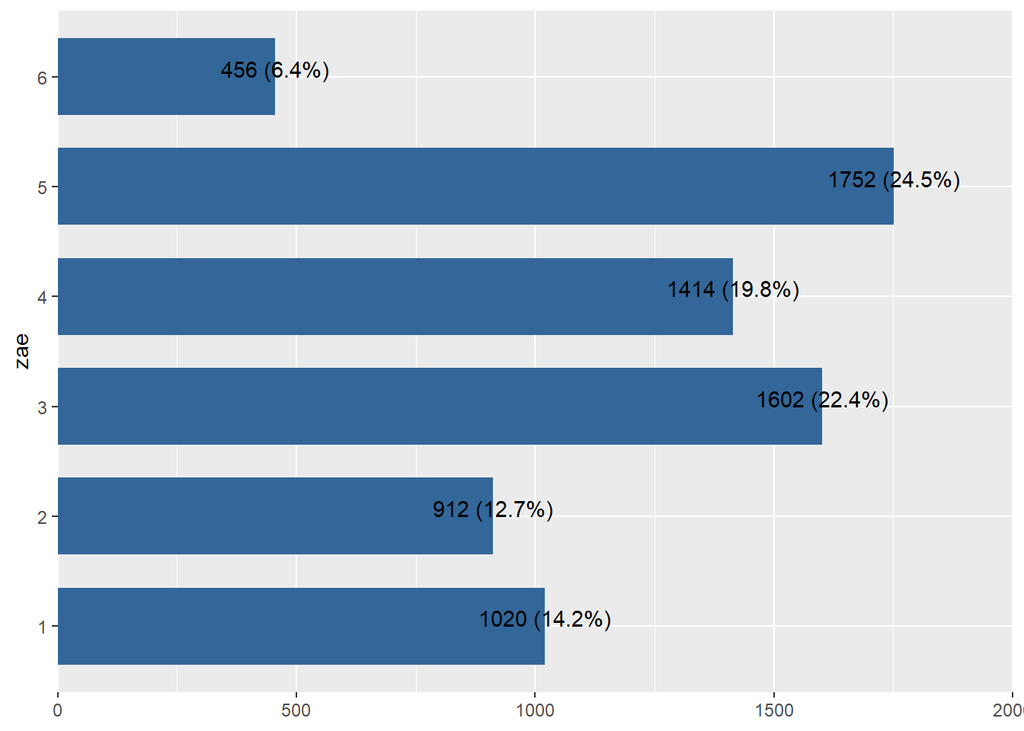

```r
wel_18 %>%
  plot_frq(coord.flip =T,zae)
```

Donc pas de label pour la variable region en 2018

```r
#View labels
expss::val_lab(wel_21$zae)
```

```
##                       Kédougou              Saint-Louis-Matam
##                              1                              3
##           Thies-Diourbel-Louga        Kaolack-Fatick-Kaffrine
##                              5                              7
## Ziguinchor-Tamba-Kolda-Sédhiou                          Dakar
##                              9                             11
```

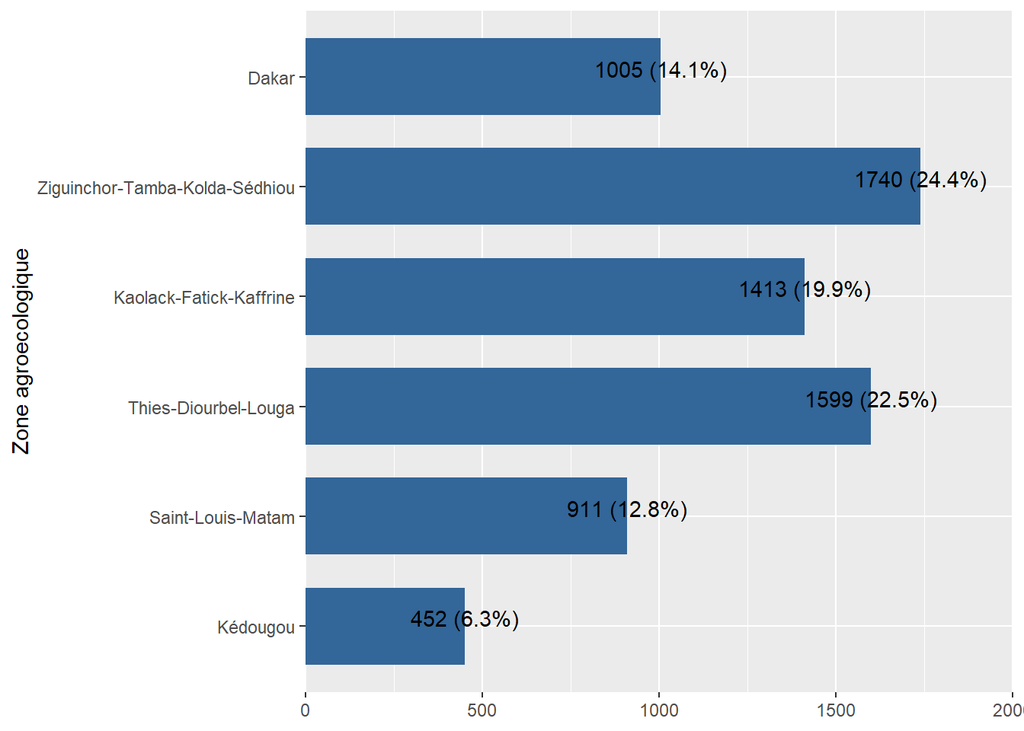

```r
wel_21 %>%
  plot_frq(coord.flip =T,zae)
```

```r
wel_18 <- wel_18 %>%
  mutate(zae = as.numeric(as.vector(zae))) %>%  # Convertir en numérique brut
  mutate(zae = recode(zae,
    1 ~ 11,  # Dakar reste 11
    2 ~ 9,   # Ziguinchor devient 9
    3 ~ 5,   # Diourbel fusionne avec Thiès (5)
    4 ~ 3,   # Saint-Louis devient 3
    5 ~ 9,   # Tambacounda fusionne avec Ziguinchor (9)
    6 ~ 7,   # Kaolack devient 7
    7 ~ 5,   # Thiès devient 5
    8 ~ 5,   # Louga fusionne avec Thiès (5)
    9 ~ 7,   # Fatick fusionne avec Kaolack (7)
    10 ~ 9,  # Kolda fusionne avec Ziguinchor (9)
    11 ~ 3,  # Matam fusionne avec Saint-Louis (3)
    12 ~ 7,  # Kaffrine fusionne avec Kaolack (7)
    13 ~ 1,  # Kédougou garde 1
    14 ~ 9   # Sédhiou fusionne avec Ziguinchor (9)
  ))
```

```r
labels_zae_2021 <- expss::val_lab(wel_21$zae)

expss::val_lab(wel_18$zae) <- labels_zae_2021

table(wel_18$zae, useNA = "ifany")
```

```
##
##              Saint-Louis-Matam           Thies-Diourbel-Louga
##                           1414                           1602
##        Kaolack-Fatick-Kaffrine Ziguinchor-Tamba-Kolda-Sédhiou
##                            456                           2664
##                          Dakar
##                           1020
```

```r
table(haven::as_factor(wel_21$zae), useNA = "ifany")
```

```
##
##                       Kédougou              Saint-Louis-Matam
##                            452                            911
##           Thies-Diourbel-Louga        Kaolack-Fatick-Kaffrine
##                           1599                           1413
## Ziguinchor-Tamba-Kolda-Sédhiou                          Dakar
##                           1740                           1005
```

region

```r
#View labels
expss::val_lab(wel_18$region)
```

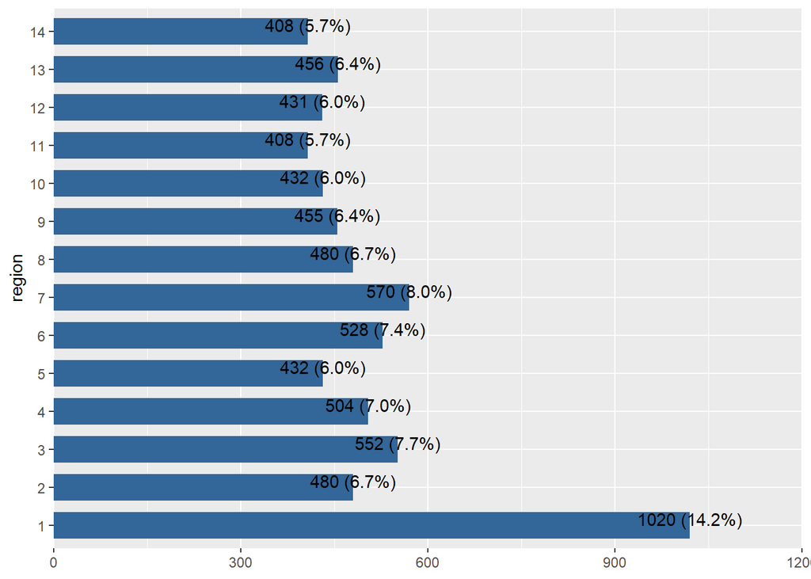

```r
wel_18 %>%
  plot_frq(coord.flip =T,region)
```

La variable région n’est pas labellisée en 2018

```r
#View labels
expss::val_lab(wel_21$region)
```

```
##       dakar  ziguinchor    diourbel SAINT-LOUIS tambacounda     kaolack
##           1           2           3           4           5           6
##       thies       louga      fatick       kolda       matam    kaffrine
##           7           8           9          10          11          12
##    kedougou     sedhiou
##          13          14
```

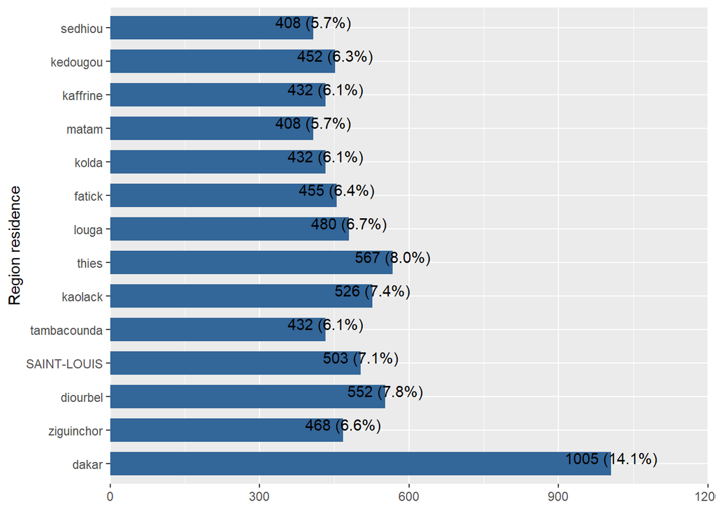

```r
wel_21 %>%
  plot_frq(coord.flip =T,region)
```

```r
region_labels <- c(
  "Dakar" = 1, "Ziguinchor" = 2, "Diourbel" = 3, "Saint-Louis" = 4,
  "Tambacounda" = 5, "Kaolack" = 6, "Thiès" = 7, "Louga" = 8,
  "Fatick" = 9, "Kolda" = 10, "Matam" = 11, "Kaffrine" = 12,
  "Kédougou" = 13, "Sédhiou" = 14
)

# Fonction pour harmoniser la variable 'zae'
harmoniser_zae <- function(data) {
  data <- data %>%
    mutate(zae = as.numeric(as.character(zae)))  # Convertir en numérique si nécessaire

  val_lab(data$zae) <- region_labels  # Appliquer les labels

  return(data)
}

# Appliquer le recodage aux deux bases
wel_18 <- harmoniser_zae(wel_18)
wel_21 <- harmoniser_zae(wel_21)

# Vérification des labels appliqués
print("Labels de la variable 'zae' dans wel_18 :")
```

```
## [1] "Labels de la variable 'zae' dans wel_18 :"
```

```r
print(val_lab(wel_18$zae))
```

```
##       Dakar  Ziguinchor    Diourbel Saint-Louis Tambacounda     Kaolack
##           1           2           3           4           5           6
##       Thiès       Louga      Fatick       Kolda       Matam    Kaffrine
##           7           8           9          10          11          12
##    Kédougou     Sédhiou
##          13          14
```

```r
print("Labels de la variable 'zae' dans wel_21 :")
```

```
## [1] "Labels de la variable 'zae' dans wel_21 :"
```

```r
print(val_lab(wel_21$zae))
```

```
##       Dakar  Ziguinchor    Diourbel Saint-Louis Tambacounda     Kaolack
##           1           2           3           4           5           6
##       Thiès       Louga      Fatick       Kolda       Matam    Kaffrine
##           7           8           9          10          11          12
##    Kédougou     Sédhiou
##          13          14
```

- Milieu de résidence (milieu)

```r
#View labels
expss::val_lab(wel_18$milieu)
```

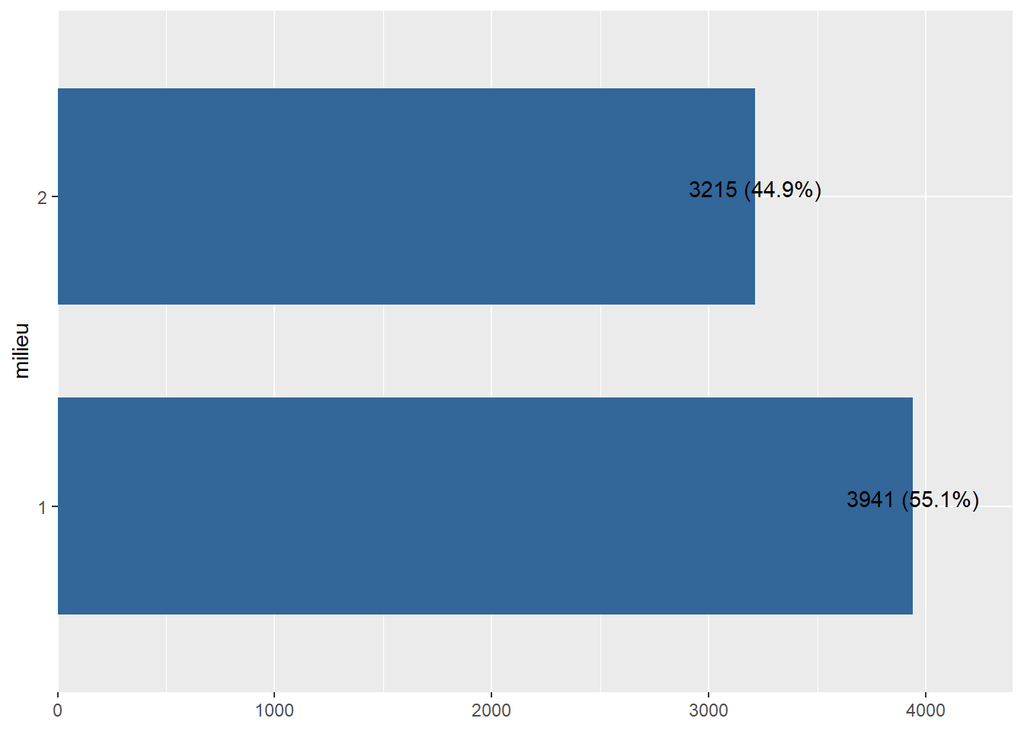

```r
wel_18 %>%
  plot_frq(coord.flip =T,milieu)
```

```r
#View labels
expss::val_lab(wel_21$milieu)
```

```
## Urbain  Rural
##      1      2
```

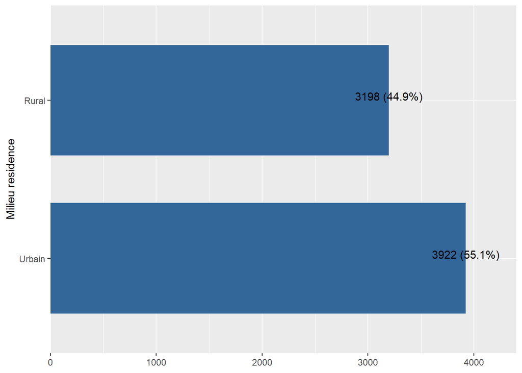

```r
wel_21 %>%
  plot_frq(coord.flip =T,milieu)
```

```r
wel_18 <- wel_18 %>%
    mutate(milieu = ifelse(milieu == 1, 1, 0))
```

```r
wel_21 <- wel_21 %>%
    mutate(milieu = ifelse(milieu == 1, 1, 0))
```

```r
val_lab(wel_18$milieu) <- c("Rural" = 0, "Urbain" = 1)
val_lab(wel_21$milieu) <- c("Rural" = 0, "Urbain" = 1)
```

```r
# Vérification des labels
print("Labels de la variable 'milieu' dans wel_18 :")
```

```
## [1] "Labels de la variable 'milieu' dans wel_18 :"
```

```r
print(val_lab(wel_18$milieu))
```

```
##  Rural Urbain
##      0      1
```

```r
print("Labels de la variable 'milieu' dans wel_21 :")
```

```
## [1] "Labels de la variable 'milieu' dans wel_21 :"
```

```r
print(val_lab(wel_21$milieu))
```

```
##  Rural Urbain
##      0      1
```

```r
# Vérification des effectifs
table(haven::as_factor(wel_18$milieu), useNA = "ifany")
```

```
##
##  Rural Urbain
##   3215   3941
```

```r
table(haven::as_factor(wel_21$milieu), useNA = "ifany")
```

```
##
##  Rural Urbain
##   3198   3922
```

### 4.0.2 Variables démographiques

- Sexe du chef de ménage (hgender)

```r
#View labels
expss::val_lab(wel_18$hgender)
```

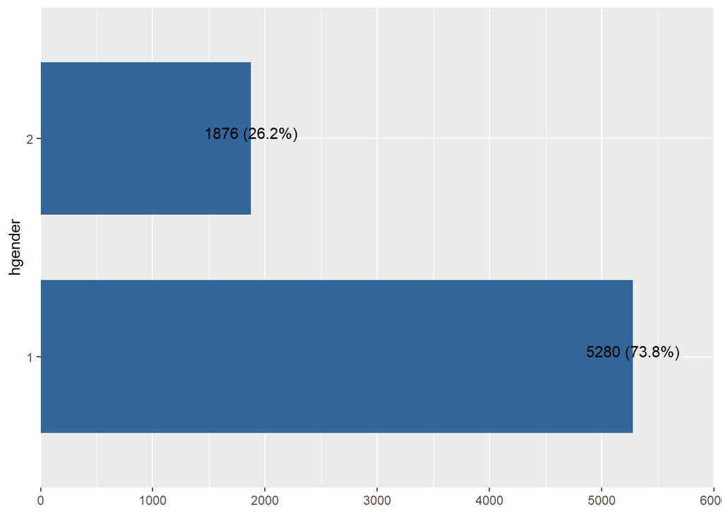

```r
wel_18 %>%
  plot_frq(coord.flip =T,hgender)
```

```r
#View labels
expss::val_lab(wel_21$hgender)
```

```
## Masculin  Féminin
##        1        2
```

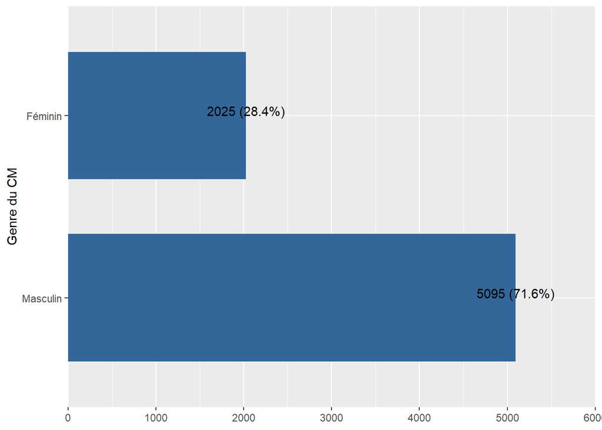

```r
wel_21 %>%
  plot_frq(coord.flip =T,hgender)
```

```r
wel_18 <- wel_18 %>%
    mutate(hgender = ifelse(hgender == 1, 1, 0))
```

```r
wel_21 <- wel_21 %>%
    mutate(hgender = ifelse(hgender == 1, 1, 0))
```

```r
val_lab(wel_18$hgender) <- c("Masculin" = 1, "Féminin" = 0)
val_lab(wel_21$hgender) <- c("Masculin" = 1, "Féminin" = 0)
```

```r
# Vérification des labels
print("Labels de la variable 'milieu' dans wel_18 :")
```

```
## [1] "Labels de la variable 'milieu' dans wel_18 :"
```

```r
print(val_lab(wel_18$hgender))
```

```
##  Féminin Masculin
##        0        1
```

```r
print("Labels de la variable 'milieu' dans wel_21 :")
```

```
## [1] "Labels de la variable 'milieu' dans wel_21 :"
```

```r
print(val_lab(wel_21$hgender))
```

```
##  Féminin Masculin
##        0        1
```

```r
# Vérification des effectifs
table(haven::as_factor(wel_18$hgender), useNA = "ifany")
```

```
##
##  Féminin Masculin
##     1876     5280
```

```r
table(haven::as_factor(wel_21$hgender), useNA = "ifany")
```

```
##
##  Féminin Masculin
##     2025     5095
```

- Statut matrimonial (hmstat)

```r
#View labels
expss::val_lab(wel_18$hmstat)
```

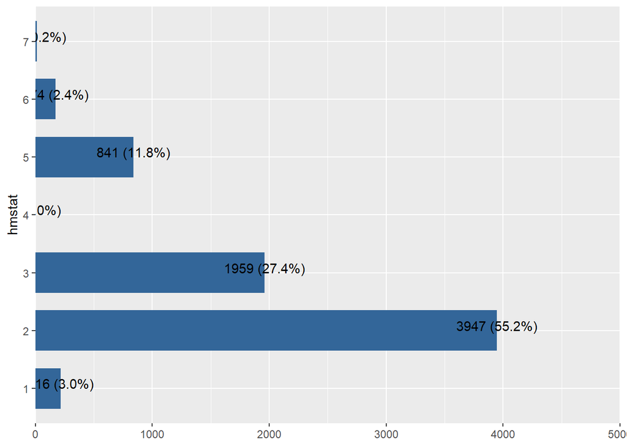

```r
wel_18 %>%
  plot_frq(coord.flip =T,hmstat)
```

```r
#View labels
expss::val_lab(wel_21$hmstat)
```

```
##       Célibataire Marié(e) monogame Marié(e) polygame       Union libre
##                 1                 2                 3                 4
##          Veuf(ve)        Divorcé(e)         Séparé(e)
##                 5                 6                 7
```

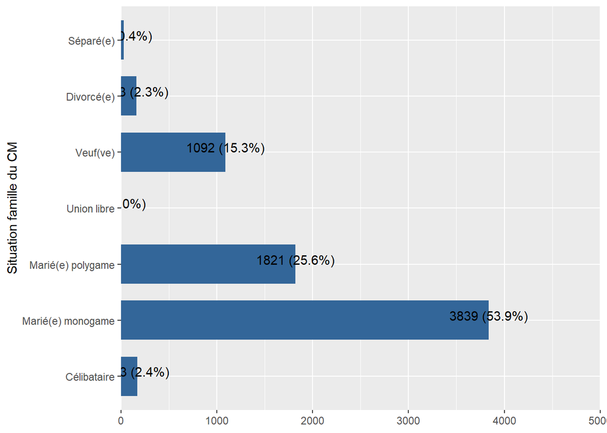

```r
wel_21 %>%
  plot_frq(coord.flip =T,hmstat)
```

```r
wel_18 <- wel_18 %>%
  mutate(
    hmstat = case_when(
      hmstat == 1 ~ 1,  # Célibataire
      hmstat == 2 ~ 2,  # Marié monogame
      hmstat == 3 ~ 3,  # Marié polygame
      hmstat == 4 ~ 4,  # Union libre
      hmstat == 5 ~ 5,  # Veuf
      hmstat == 6 ~ 6,  # Divorcé
      hmstat == 7 ~ 7,  # Séparé
      TRUE ~ NA_real_
    )
  )
labels_hmstat_2021 <- expss::val_lab(wel_21$hmstat)

expss::val_lab(wel_18$hmstat) <- labels_hmstat_2021
```

```r
# Vérification des labels
print("Labels de la variable 'milieu' dans wel_18 :")
```

```
## [1] "Labels de la variable 'milieu' dans wel_18 :"
```

```r
print(val_lab(wel_18$hmstat))
```

```
##       Célibataire Marié(e) monogame Marié(e) polygame       Union libre
##                 1                 2                 3                 4
##          Veuf(ve)        Divorcé(e)         Séparé(e)
##                 5                 6                 7
```

```r
print("Labels de la variable 'milieu' dans wel_21 :")
```

```
## [1] "Labels de la variable 'milieu' dans wel_21 :"
```

```r
print(val_lab(wel_21$hmstat))
```

```
##       Célibataire Marié(e) monogame Marié(e) polygame       Union libre
##                 1                 2                 3                 4
##          Veuf(ve)        Divorcé(e)         Séparé(e)
##                 5                 6                 7
```

```r
table(haven::as_factor(wel_18$hmstat), useNA = "ifany")
```

```
##
##       Célibataire Marié(e) monogame Marié(e) polygame       Union libre
##               216              3947              1959                 3
##          Veuf(ve)        Divorcé(e)         Séparé(e)              <NA>
##               841               174                14                 2
```

```r
table(haven::as_factor(wel_21$hmstat), useNA = "ifany")
```

```
##
##       Célibataire Marié(e) monogame Marié(e) polygame       Union libre
##               173              3839              1821                 1
##          Veuf(ve)        Divorcé(e)         Séparé(e)
##              1092               163                31
```

- Religion (hreligion)

```r
#View labels
expss::val_lab(wel_18$hreligion)
```

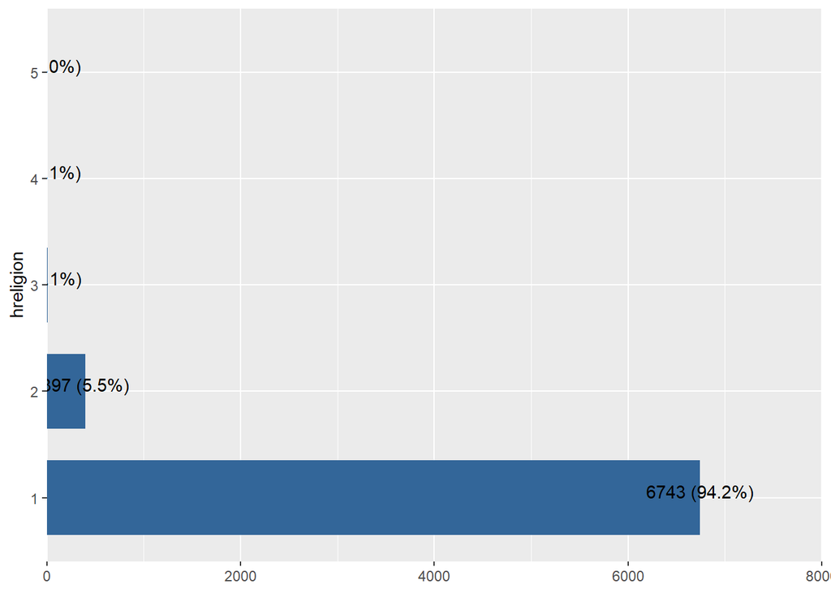

```r
wel_18 %>% plot_frq(coord.flip =T,hreligion)
```

```r
#View labels
expss::val_lab(wel_21$hreligion)
```

```
##       Musulman       Chrétien       Animiste Autre Réligion  Sans Réligion
##              1              2              3              4              5
```

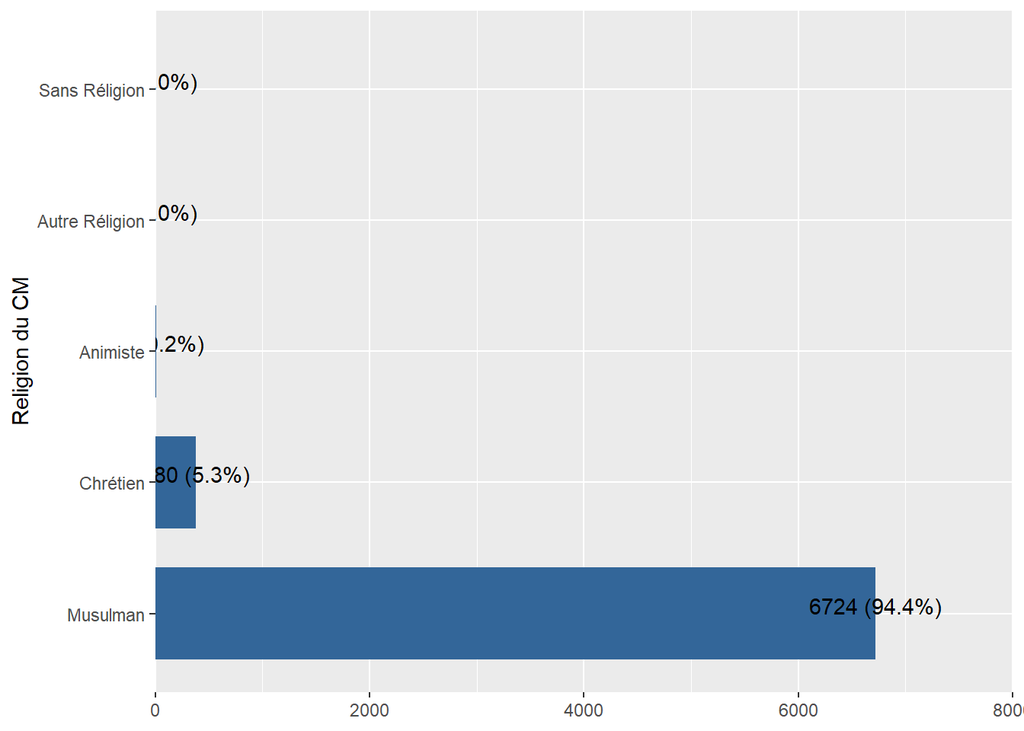

```r
wel_21 %>%
  plot_frq(coord.flip =T,hreligion)
```

```r
labels_religion_2021 <- expss::val_lab(wel_21$hreligion)

expss::val_lab(wel_18$hreligion) <- labels_religion_2021
```

```r
# Vérification des labels
print("Labels de la variable 'hreligion' dans wel_18 :")
```

```
## [1] "Labels de la variable 'hreligion' dans wel_18 :"
```

```r
print(val_lab(wel_18$hreligion))
```

```
##       Musulman       Chrétien       Animiste Autre Réligion  Sans Réligion
##              1              2              3              4              5
```

```r
print("Labels de la variable 'milieu' dans wel_21 :")
```

```
## [1] "Labels de la variable 'milieu' dans wel_21 :"
```

```r
print(val_lab(wel_21$hreligion))
```

```
##       Musulman       Chrétien       Animiste Autre Réligion  Sans Réligion
##              1              2              3              4              5
```

```r
# Vérification des effectifs
table(haven::as_factor(wel_18$hreligion), useNA = "ifany")
```

```
##
##       Musulman       Chrétien       Animiste Autre Réligion  Sans Réligion
##           6743            397              8              5              3
```

```r
table(haven::as_factor(wel_21$hreligion), useNA = "ifany")
```

```
##
##       Musulman       Chrétien       Animiste Autre Réligion  Sans Réligion
##           6724            380             13              2              1
```

### 4.0.3 Caractéristiques du chef de ménage

#### 4.0.3.1 Activités du chef de ménage

- Activité sur 7 jours (hactiv7j)

```r
#View labels
expss::val_lab(wel_18$hactiv7j)
```

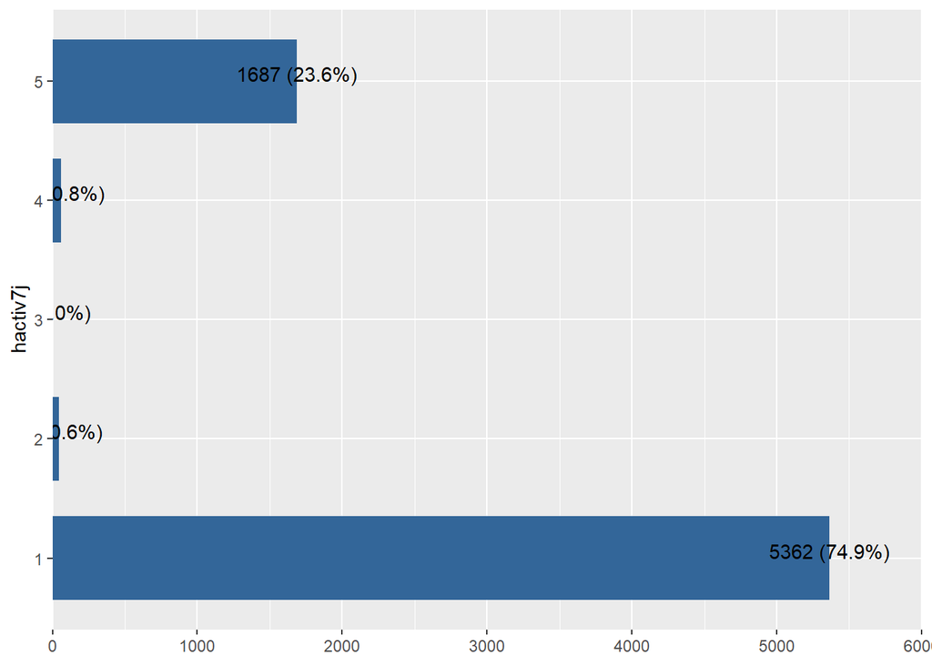

```r
wel_18 %>%
  plot_frq(coord.flip =T,hactiv7j)
```

```r
#View labels
expss::val_lab(wel_21$hactiv7j)
```

```
##              Occupe TF cherchant emploi    TF cherchant pas             Chomeur
##                   1                   2                   3                   4
##             Inactif      Moins de 5 ans
##                   5                   6
```

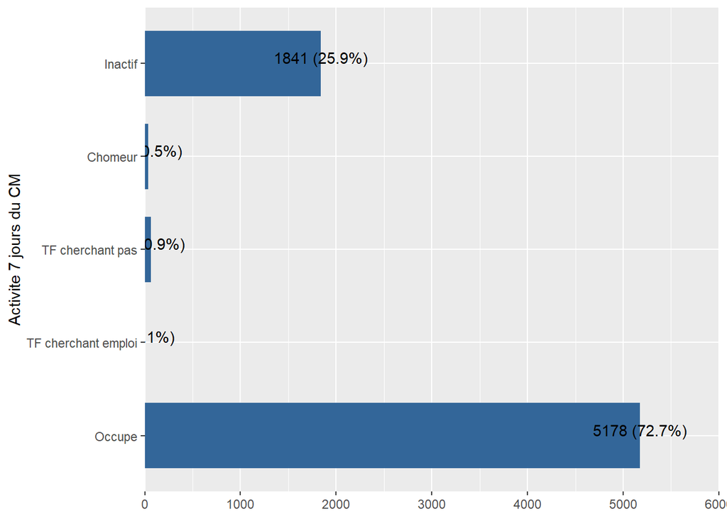

```r
wel_21 %>%
  plot_frq(coord.flip =T,hactiv7j)
```

```r
# Recodage pour harmoniser avec 'wel_21$hactiv7j'
wel_18$hactiv7j <- dplyr::recode(wel_18$hactiv7j,
                                 `2` = 4,  # Chômeur devient 4
                                 `3` = 2,  # TF cherchant emploi devient 2
                                 `4` = 3,  # TF cherchant pas reste 3
                                 `1` = 1,  # Occupe reste 1
                                 `5` = 5,  # Inactif reste 5
                                 `6` = 6)  # Moins de 5 ans reste 6

# Appliquer les labels de 2021 à la variable recodée
expss::val_lab(wel_18$hactiv7j) <- expss::val_lab(wel_21$hactiv7j)

# Vérification des labels et des valeurs après recodage
print("Labels après harmonisation de 'hactiv7j' dans wel_18 :")
```

```
## [1] "Labels après harmonisation de 'hactiv7j' dans wel_18 :"
```

```r
print(expss::val_lab(wel_18$hactiv7j))
```

```
##              Occupe TF cherchant emploi    TF cherchant pas             Chomeur
##                   1                   2                   3                   4
##             Inactif      Moins de 5 ans
##                   5                   6
```

```r
print("Table de fréquences après recodage :")
```

```
## [1] "Table de fréquences après recodage :"
```

```r
print(table(wel_18$hactiv7j, useNA = "ifany"))
```

```
##
##              Occupe TF cherchant emploi    TF cherchant pas             Chomeur
##                5362                   3                  60                  44
##             Inactif
##                1687
```

```r
table(haven::as_factor(wel_18$hactiv7j), useNA = "ifany")
```

```
##
##              Occupe TF cherchant emploi    TF cherchant pas             Chomeur
##                5362                   3                  60                  44
##             Inactif      Moins de 5 ans
##                1687                   0
```

```r
table(haven::as_factor(wel_21$hactiv7j), useNA = "ifany")
```

```
##
##              Occupe TF cherchant emploi    TF cherchant pas             Chomeur
##                5178                   5                  62                  34
##             Inactif      Moins de 5 ans
##                1841                   0
```

- Branche d’activité (hbranch)

```r
#View labels
expss::val_lab(wel_18$hbranch)
```

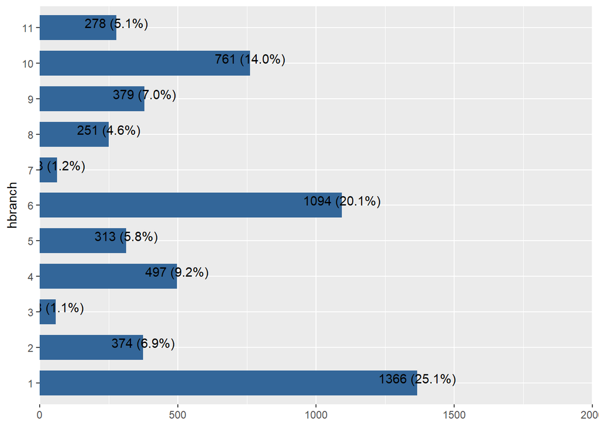

```r
wel_18 %>%
  plot_frq(coord.flip =T,hbranch)
```

```r
#View labels
expss::val_lab(wel_21$hbranch)
```

```
##        Agriculture Elevage/syl./peche      Indust. extr.      Autr. indust.
##                  1                  2                  3                  4
##                btp           Commerce   Restaurant/Hotel       Trans./Comm.
##                  5                  6                  7                  8
##    Education/Sante    Services perso.      Aut. services
##                  9                 10                 11
```

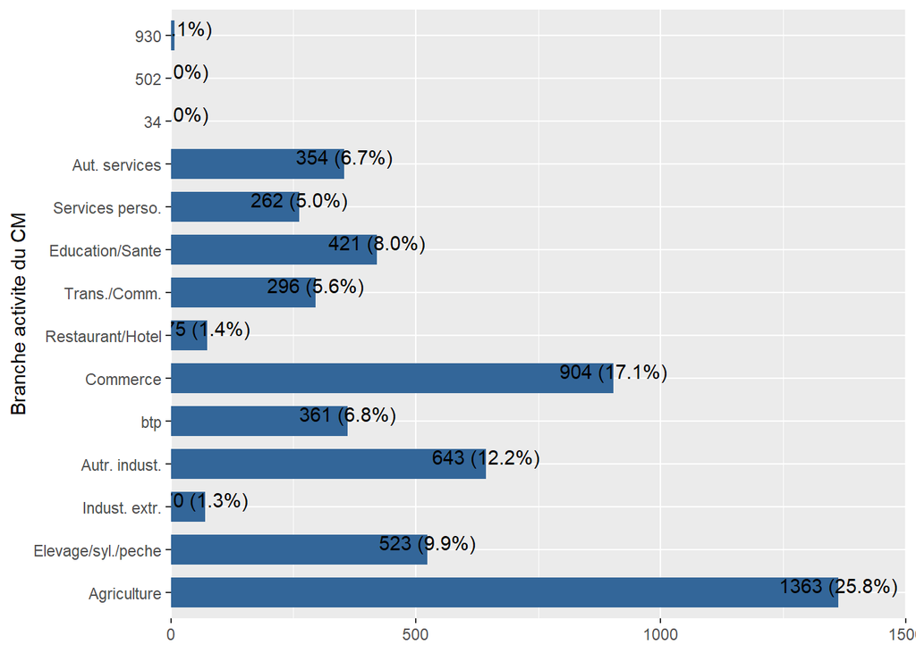

```r
wel_21 %>%
  plot_frq(coord.flip =T,hbranch)
```

```r
# Recoder 'wel_18$hbranch' pour harmoniser avec 'wel_21$hbranch'
wel_18$hbranch <- dplyr::recode(wel_18$hbranch,
                                `2` = 2)  # Recode "Elevage/peche" en "Elevage/syl./peche" (valeur 2 reste inchangée ici)

# Appliquer les mêmes labels de 'wel_21$hbranch' à 'wel_18$hbranch'
expss::val_lab(wel_18$hbranch) <- expss::val_lab(wel_21$hbranch)

# Vérifier les labels après recodage
print("Labels après harmonisation de 'hbranch' dans wel_18 :")
```

```
## [1] "Labels après harmonisation de 'hbranch' dans wel_18 :"
```

```r
print(expss::val_lab(wel_18$hbranch))
```

```
##        Agriculture Elevage/syl./peche      Indust. extr.      Autr. indust.
##                  1                  2                  3                  4
##                btp           Commerce   Restaurant/Hotel       Trans./Comm.
##                  5                  6                  7                  8
##    Education/Sante    Services perso.      Aut. services
##                  9                 10                 11
```

```r
table(haven::as_factor(wel_18$hbranch), useNA = "ifany")
```

```
##
##        Agriculture Elevage/syl./peche      Indust. extr.      Autr. indust.
##                  0                374                  0                  0
##                btp           Commerce   Restaurant/Hotel       Trans./Comm.
##                  0                  0                  0                  0
##    Education/Sante    Services perso.      Aut. services               <NA>
##                  0                  0                  0               6782
```

```r
table(haven::as_factor(wel_21$hbranch), useNA = "ifany")
```

```
##
##        Agriculture Elevage/syl./peche      Indust. extr.      Autr. indust.
##               1363                523                 70                643
##                btp           Commerce   Restaurant/Hotel       Trans./Comm.
##                361                904                 75                296
##    Education/Sante    Services perso.      Aut. services                 34
##                421                262                354                  1
##                502                930               <NA>
##                  1                  8               1838
```

- Secteur institutionnel (hsectins)

```r
#View labels
expss::val_lab(wel_18$hsectins)
```

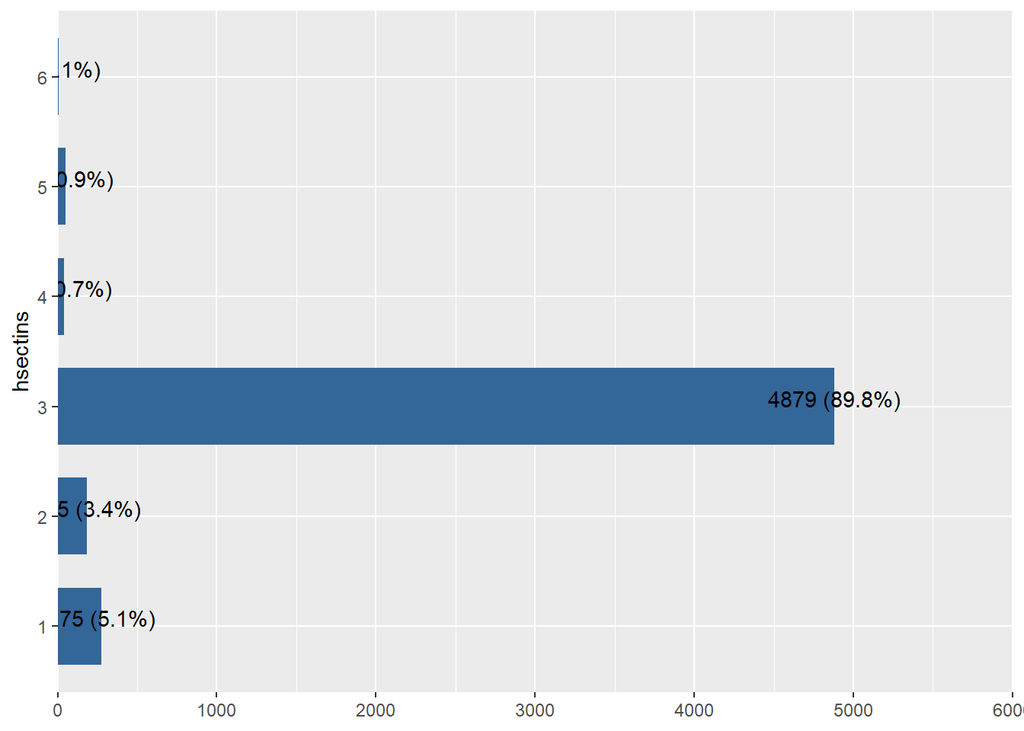

```r
wel_18 %>%
  plot_frq(coord.flip =T,hsectins)
```

```r
#View labels
expss::val_lab(wel_21$hsectins)
```

```
##                     Etat/Collectivités locales
##                                              1
##              Entreprise publique/ parapublique
##                                              2
##                              Entreprise Privée
##                                              3
##                         Entreprise associative
##                                              4
## Ménage comme employeur de personnel domestique
##                                              5
##             Organisme international /Ambassade
##                                              6
```

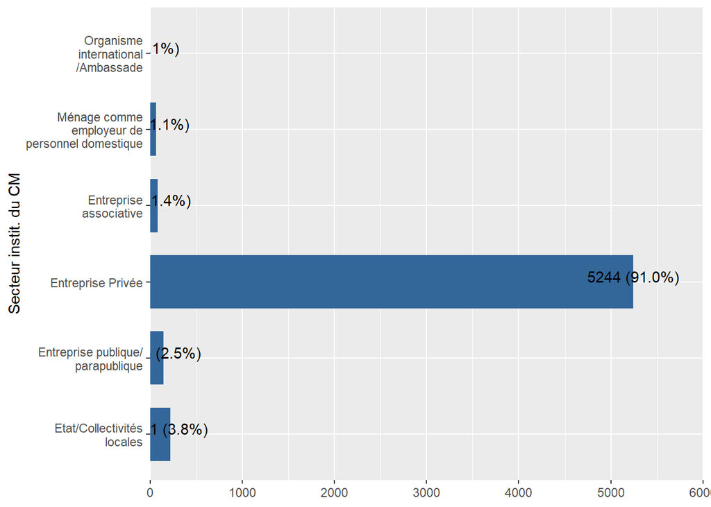

```r
wel_21 %>%
  plot_frq(coord.flip =T,hsectins)
```

```r
labels_hsectins_2021 <- expss::val_lab(wel_21$hsectins)

expss::val_lab(wel_18$hsectins) <- labels_hsectins_2021
```

```r
# Vérification des labels
print("Labels de la variable 'hsectins' dans wel_18 :")
```

```
## [1] "Labels de la variable 'hsectins' dans wel_18 :"
```

```r
print(val_lab(wel_18$hsectins))
```

```
##                     Etat/Collectivités locales
##                                              1
##              Entreprise publique/ parapublique
##                                              2
##                              Entreprise Privée
##                                              3
##                         Entreprise associative
##                                              4
## Ménage comme employeur de personnel domestique
##                                              5
##             Organisme international /Ambassade
##                                              6
```

```r
print("Labels de la variable 'hsectins' dans wel_21 :")
```

```
## [1] "Labels de la variable 'hsectins' dans wel_21 :"
```

```r
print(val_lab(wel_21$hsectins))
```

```
##                     Etat/Collectivités locales
##                                              1
##              Entreprise publique/ parapublique
##                                              2
##                              Entreprise Privée
##                                              3
##                         Entreprise associative
##                                              4
## Ménage comme employeur de personnel domestique
##                                              5
##             Organisme international /Ambassade
##                                              6
```

```r
table(wel_18$hmstat, useNA = "ifany")
```

```
##
##       Célibataire Marié(e) monogame Marié(e) polygame       Union libre
##               216              3947              1959                 3
##          Veuf(ve)        Divorcé(e)         Séparé(e)              <NA>
##               841               174                14                 2
```

```r
table(haven::as_factor(wel_21$hsectins), useNA = "ifany")
```

```
##
##                     Etat/Collectivités locales
##                                            221
##              Entreprise publique/ parapublique
##                                            146
##                              Entreprise Privée
##                                           5244
##                         Entreprise associative
##                                             81
## Ménage comme employeur de personnel domestique
##                                             64
##             Organisme international /Ambassade
##                                              5
##                                           <NA>
##                                           1359
```

- Categorie soio-professionnelle (hcsp)

```r
#View labels
expss::val_lab(wel_18$hcsp)
```

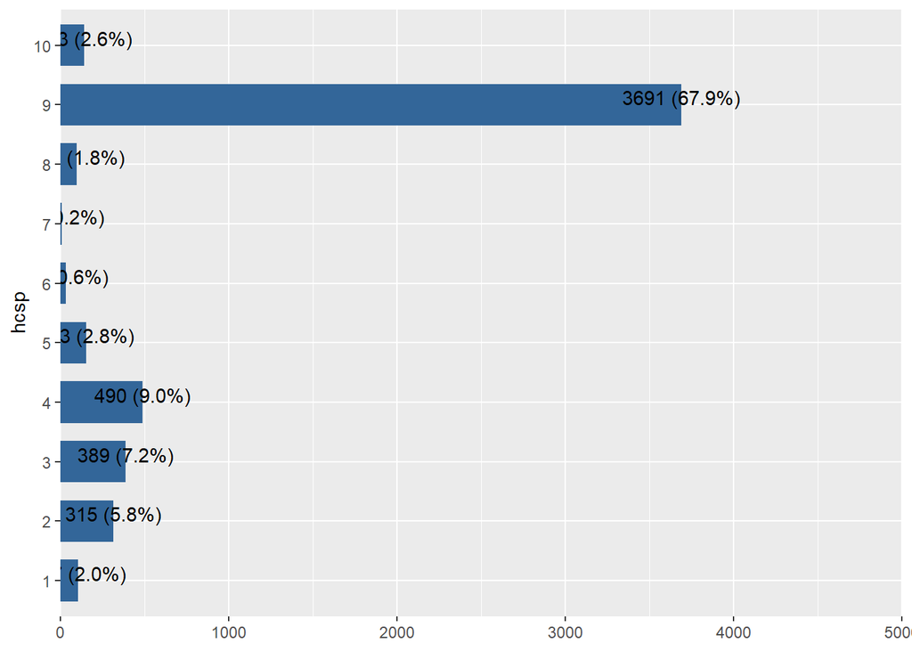

```r
wel_18 %>%
  plot_frq(coord.flip =T,hcsp)
```

```r
#View labels
expss::val_lab(wel_21$hcsp)
```

```
##                                               Cadre supérieur
##                                                             1
##                                 Cadre moyen/agent de maîtrise
##                                                             2
##                                   Ouvrier ou employé qualifié
##                                                             3
##                               Ouvrier ou employé non qualifié
##                                                             4
##                                       Manœuvre, aide ménagère
##                                                             5
##                                Stagiaire ou Apprenti rénuméré
##                                                             6
##                            Stagiaire ou Apprenti non rénuméré
##                                                             7
## Travailleur Familial contribuant pour une entreprise familial
##                                                             8
##                                Travailleur pour compte propre
##                                                             9
##                                                        Patron
##                                                            10
```

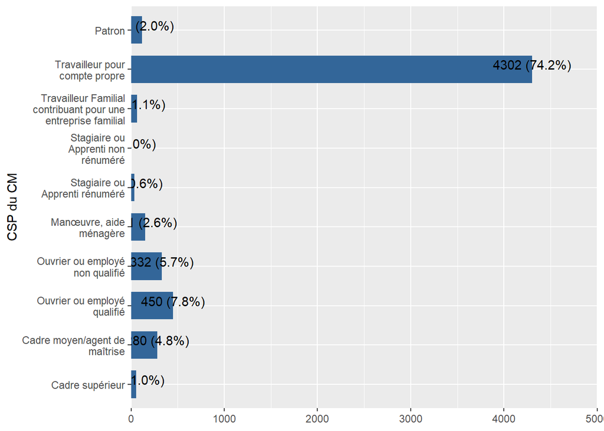

```r
wel_21 %>%
  plot_frq(coord.flip =T,hcsp)
```

```r
labels_hcsp_2021 <- expss::val_lab(wel_21$hcsp)

expss::val_lab(wel_18$hcsp) <- labels_hcsp_2021
```

```r
# Vérification des labels
print("Labels de la variable 'hcsp' dans wel_18 :")
```

```
## [1] "Labels de la variable 'hcsp' dans wel_18 :"
```

```r
print(val_lab(wel_18$hcsp))
```

```
##                                               Cadre supérieur
##                                                             1
##                                 Cadre moyen/agent de maîtrise
##                                                             2
##                                   Ouvrier ou employé qualifié
##                                                             3
##                               Ouvrier ou employé non qualifié
##                                                             4
##                                       Manœuvre, aide ménagère
##                                                             5
##                                Stagiaire ou Apprenti rénuméré
##                                                             6
##                            Stagiaire ou Apprenti non rénuméré
##                                                             7
## Travailleur Familial contribuant pour une entreprise familial
##                                                             8
##                                Travailleur pour compte propre
##                                                             9
##                                                        Patron
##                                                            10
```

```r
print("Labels de la variable 'hcsp' dans wel_21 :")
```

```
## [1] "Labels de la variable 'hcsp' dans wel_21 :"
```

```r
print(val_lab(wel_21$hsectins))
```

```
##                     Etat/Collectivités locales
##                                              1
##              Entreprise publique/ parapublique
##                                              2
##                              Entreprise Privée
##                                              3
##                         Entreprise associative
##                                              4
## Ménage comme employeur de personnel domestique
##                                              5
##             Organisme international /Ambassade
##                                              6
```

```r
table(haven::as_factor(wel_18$hcsp), useNA = "ifany")
```

```
##
##                                               Cadre supérieur
##                                                           107
##                                                        Patron
##                                                           143
##                                 Cadre moyen/agent de maîtrise
##                                                           315
##                                   Ouvrier ou employé qualifié
##                                                           389
##                               Ouvrier ou employé non qualifié
##                                                           490
##                                       Manœuvre, aide ménagère
##                                                           153
##                                Stagiaire ou Apprenti rénuméré
##                                                            35
##                            Stagiaire ou Apprenti non rénuméré
##                                                            11
## Travailleur Familial contribuant pour une entreprise familial
##                                                           100
##                                Travailleur pour compte propre
##                                                          3691
##                                                          <NA>
##                                                          1722
```

```r
table(haven::as_factor(wel_21$hcsp), useNA = "ifany")
```

```
##
##                                               Cadre supérieur
##                                                            57
##                                 Cadre moyen/agent de maîtrise
##                                                           280
##                                   Ouvrier ou employé qualifié
##                                                           450
##                               Ouvrier ou employé non qualifié
##                                                           332
##                                       Manœuvre, aide ménagère
##                                                           151
##                                Stagiaire ou Apprenti rénuméré
##                                                            34
##                            Stagiaire ou Apprenti non rénuméré
##                                                             3
## Travailleur Familial contribuant pour une entreprise familial
##                                                            66
##                                Travailleur pour compte propre
##                                                          4302
##                                                        Patron
##                                                           119
##                                                          <NA>
##                                                          1326
```

- Alphabétisation (halfab)

```r
#View labels
expss::val_lab(wel_18$halfab)
```

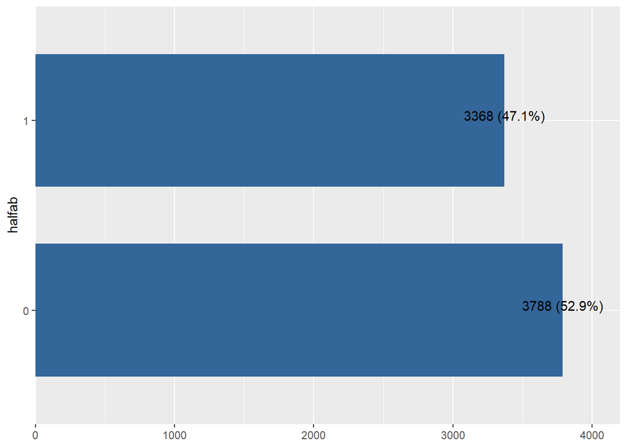

```r
wel_18 %>%
  plot_frq(coord.flip =T,halfab)
```

```r
#View labels
expss::val_lab(wel_21$halfab)
```

```
## Non Oui
##   0   1
```

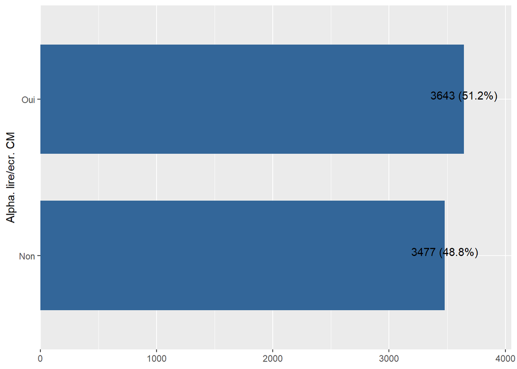

```r
wel_21 %>%
  plot_frq(coord.flip =T,halfab)
```

```r
labels_halfab_2021 <- expss::val_lab(wel_21$halfab)

expss::val_lab(wel_18$halfab) <- labels_halfab_2021
```

```r
# Vérification des labels
print("Labels de la variable 'halfab' dans wel_18 :")
```

```
## [1] "Labels de la variable 'halfab' dans wel_18 :"
```

```r
print(val_lab(wel_18$halfab))
```

```
## Non Oui
##   0   1
```

```r
print("Labels de la variable 'halfab' dans wel_21 :")
```

```
## [1] "Labels de la variable 'halfab' dans wel_21 :"
```

```r
print(val_lab(wel_21$halfab))
```

```
## Non Oui
##   0   1
```

```r
table(haven::as_factor(wel_18$halfab), useNA = "ifany")
```

```
##
##  Non  Oui
## 3788 3368
```

```r
table(haven::as_factor(wel_21$halfab), useNA = "ifany")
```

```
##
##  Non  Oui
## 3477 3643
```

- Nationalité (hnation)

Variables nécessitant un regroupement de modalités (hnation)

```r
#View labels
expss::val_lab(wel_18$hnation)
```

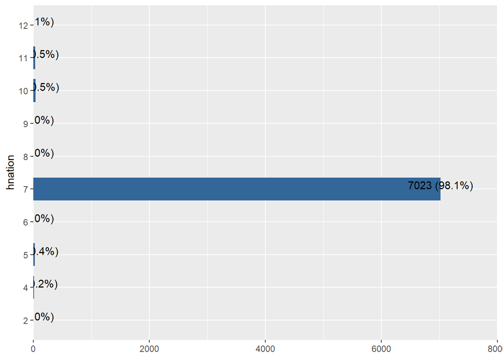

```r
wel_18 %>%
  plot_frq(coord.flip =T,hnation)
```

```r
#View labels
expss::val_lab(wel_21$hnation)
```

```
##                   Bénin            Burkina Faso               Cape-vert
##                       1                       2                       3
##           Cote d'ivoire                  Gambie                   Ghana
##                       4                       5                       6
##                  Guinee           Guinée Bissau                 Liberia
##                       7                       8                       9
##                    Mali                   Niger                 Nigeria
##                      10                      11                      12
##                 Sénégal            Serra-Leonne                    Togo
##                      13                      14                      15
##           Autre Afrique Autre pays hors Afrique
##                      17                      18
```

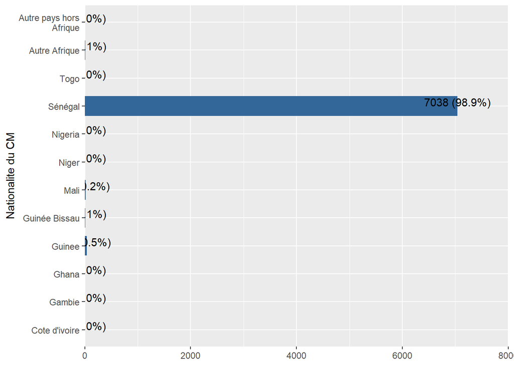

```r
wel_21 %>%
  plot_frq(coord.flip =T,hnation)
```

```r
wel_21 <- wel_21 %>%
  mutate(hnation = dplyr::recode(hnation,
                          `4` = 3,  # Remplace la modalité 4 par 3
                          `8` = 4,  # Remplace la modalité 8 par 4
                          `10` = 5, # Remplace la modalité 10 par 5
                          `11` = 6, # Remplace la modalité 11 par 6
                          `13` = 7, # Remplace la modalité 13 par 7
                          `15` = 8, # Remplace la modalité 15 par 8
                          `12` = 9, # Remplace la modalité 12 par 9
                          `17` = 11, # Remplace la modalité 17 par 11
                          `18` = 12, # Remplace la modalité 18 par 12
                          `3` = 10, `5` = 10, `6` = 10, `7` = 10, `9` = 10, `14` = 10 # Remplace les modalités (3,9,14,5,6,7) par 10
                          ))
```

```r
labels_hnation_2021 <- expss::val_lab(wel_21$hnation)

expss::val_lab(wel_18$hnation) <- labels_hnation_2021
```

```r
# Vérification des labels
print("Labels de la variable 'halfab' dans wel_18 :")
```

```
## [1] "Labels de la variable 'halfab' dans wel_18 :"
```

```r
print(val_lab(wel_18$hnation))
```

```
##                   Bénin            Burkina Faso               Cape-vert
##                       1                       2                       3
##           Cote d'ivoire                  Gambie                   Ghana
##                       4                       5                       6
##                  Guinee           Guinée Bissau                 Liberia
##                       7                       8                       9
##                    Mali                   Niger                 Nigeria
##                      10                      11                      12
##                 Sénégal            Serra-Leonne                    Togo
##                      13                      14                      15
##           Autre Afrique Autre pays hors Afrique
##                      17                      18
```

```r
print("Labels de la variable 'halfab' dans wel_21 :")
```

```
## [1] "Labels de la variable 'halfab' dans wel_21 :"
```

```r
print(val_lab(wel_21$hnation))
```

```
##                   Bénin            Burkina Faso               Cape-vert
##                       1                       2                       3
##           Cote d'ivoire                  Gambie                   Ghana
##                       4                       5                       6
##                  Guinee           Guinée Bissau                 Liberia
##                       7                       8                       9
##                    Mali                   Niger                 Nigeria
##                      10                      11                      12
##                 Sénégal            Serra-Leonne                    Togo
##                      13                      14                      15
##           Autre Afrique Autre pays hors Afrique
##                      17                      18
```

```r
table(haven::as_factor(wel_18$hnation), useNA = "ifany")
```

```
##
##                   Bénin                    Mali                   Niger
##                       0                      39                      37
##                 Nigeria                 Sénégal            Serra-Leonne
##                       4                       0                       0
##                    Togo           Autre Afrique Autre pays hors Afrique
##                       0                       0                       0
##            Burkina Faso               Cape-vert           Cote d'ivoire
##                       1                       0                      18
##                  Gambie                   Ghana                  Guinee
##                      27                       3                    7023
##           Guinée Bissau                 Liberia
##                       2                       2
```

```r
table(haven::as_factor(wel_21$hnation), useNA = "ifany")
```

```
##
##                   Bénin            Burkina Faso               Cape-vert
##                       0                       0                       1
##           Cote d'ivoire                  Gambie                   Ghana
##                       8                      18                       2
##                  Guinee           Guinée Bissau                 Liberia
##                    7038                       1                       1
##                    Mali                   Niger                 Nigeria
##                      42                       7                       2
##                 Sénégal            Serra-Leonne                    Togo
##                       0                       0                       0
##           Autre Afrique Autre pays hors Afrique
##                       0                       0
```

- Activité sur 12 mois (hactiv12m)

```r
#View labels
expss::val_lab(wel_18$hactiv12m)
```

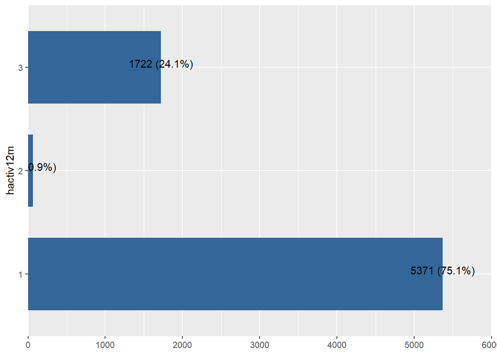

```r
wel_18 %>%
  plot_frq(coord.flip =T,hactiv12m)
```

```r
#View labels
expss::val_lab(wel_21$hactiv12m)
```

```
##         Occupe     Trav. fam.     Non occupe Moins de 5 ans
##              1              2              3              4
```

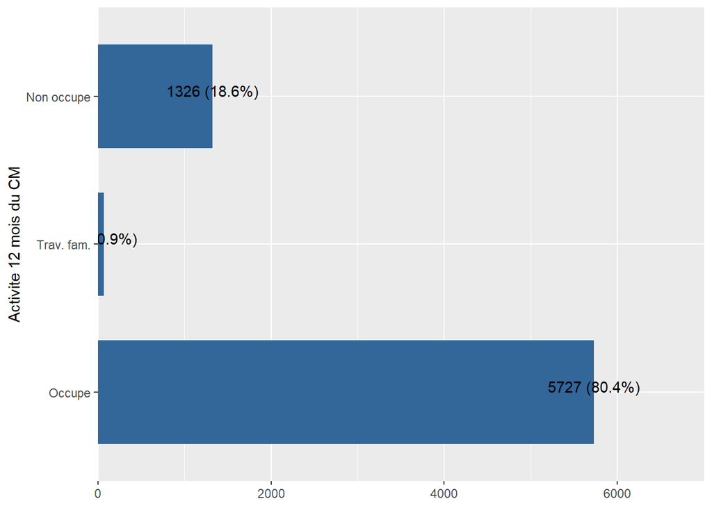

```r
wel_21 %>%
  plot_frq(coord.flip =T,hactiv12m)
```

```r
labels_hactiv12m_2021 <- expss::val_lab(wel_21$hactiv12m)

expss::val_lab(wel_18$hactiv12m) <- labels_hactiv12m_2021
```

```r
# Vérification des labels
print("Labels de la variable 'hactiv12m' dans wel_18 :")
```

```
## [1] "Labels de la variable 'hactiv12m' dans wel_18 :"
```

```r
print(val_lab(wel_18$hactiv12m))
```

```
##         Occupe     Trav. fam.     Non occupe Moins de 5 ans
##              1              2              3              4
```

```r
print("Labels de la variable 'hactiv12m' dans wel_21 :")
```

```
## [1] "Labels de la variable 'hactiv12m' dans wel_21 :"
```

```r
print(val_lab(wel_21$hactiv12m))
```

```
##         Occupe     Trav. fam.     Non occupe Moins de 5 ans
##              1              2              3              4
```

```r
table(haven::as_factor(wel_18$hactiv12m), useNA = "ifany")
```

```
##
##         Occupe     Trav. fam.     Non occupe Moins de 5 ans
##           5371             63           1722              0
```

```r
table(haven::as_factor(wel_21$hactiv12m), useNA = "ifany")
```

```
##
##         Occupe     Trav. fam.     Non occupe Moins de 5 ans
##           5727             67           1326              0
```

#### 4.0.3.2 Education

- niveau d’éducation (heduc)

```r
#View labels
expss::val_lab(wel_18$heduc)
```

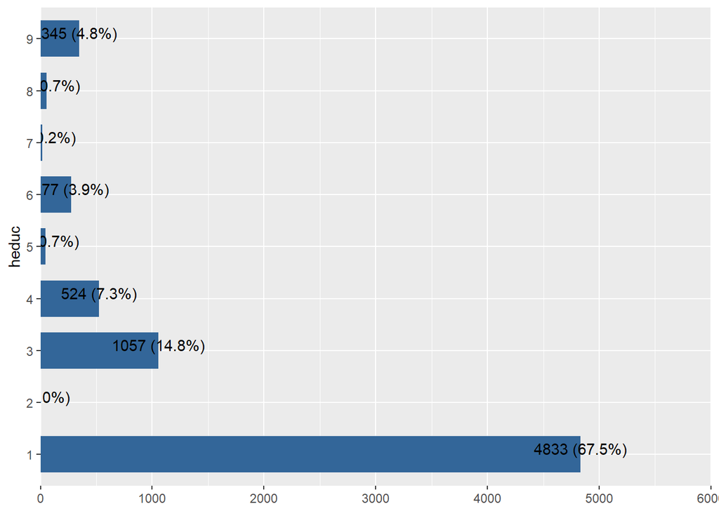

```r
wel_18 %>%
  plot_frq(coord.flip =T,heduc)
```

```r
#View labels
expss::val_lab(wel_21$heduc)
```

```
##           Aucun      Maternelle        Primaire    Second. gl 1 Second. tech. 1
##               1               2               3               4               5
##    Second. gl 2 Second. tech. 2  Postsecondaire       Superieur
##               6               7               8               9
```

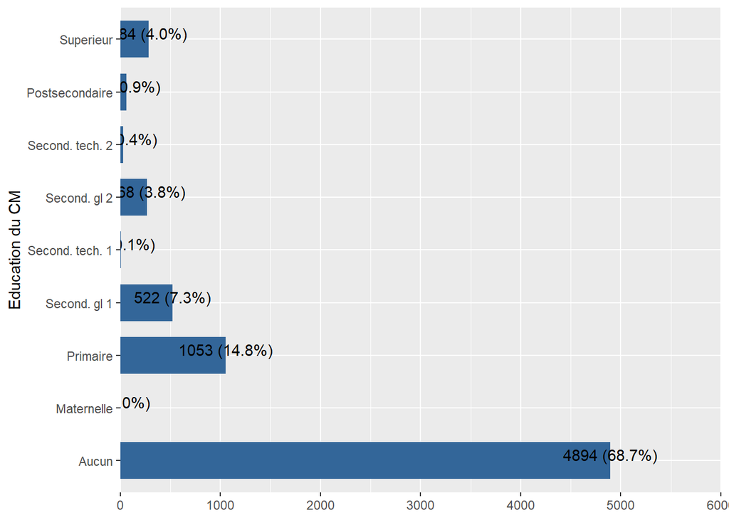

```r
wel_21 %>%
  plot_frq(coord.flip =T,heduc)
```

```r
labels_heduc_2021 <- expss::val_lab(wel_21$heduc)

expss::val_lab(wel_18$heduc) <- labels_heduc_2021
```

```r
# Vérification des labels
print("Labels de la variable 'heduc' dans wel_18 :")
```

```
## [1] "Labels de la variable 'heduc' dans wel_18 :"
```

```r
print(val_lab(wel_18$heduc))
```

```
##           Aucun      Maternelle        Primaire    Second. gl 1 Second. tech. 1
##               1               2               3               4               5
##    Second. gl 2 Second. tech. 2  Postsecondaire       Superieur
##               6               7               8               9
```

```r
print("Labels de la variable 'heduc' dans wel_21 :")
```

```
## [1] "Labels de la variable 'heduc' dans wel_21 :"
```

```r
print(val_lab(wel_21$heduc))
```

```
##           Aucun      Maternelle        Primaire    Second. gl 1 Second. tech. 1
##               1               2               3               4               5
##    Second. gl 2 Second. tech. 2  Postsecondaire       Superieur
##               6               7               8               9
```

```r
table(haven::as_factor(wel_18$heduc), useNA = "ifany")
```

```
##
##           Aucun      Maternelle        Primaire    Second. gl 1 Second. tech. 1
##            4833               2            1057             524              47
##    Second. gl 2 Second. tech. 2  Postsecondaire       Superieur
##             277              18              53             345
```

```r
table(haven::as_factor(wel_21$heduc), useNA = "ifany")
```

```
##
##           Aucun      Maternelle        Primaire    Second. gl 1 Second. tech. 1
##            4894               1            1053             522              10
##    Second. gl 2 Second. tech. 2  Postsecondaire       Superieur
##             268              27              61             284
```

- Diplôme (hdiploma)

```r
#View labels
expss::val_lab(wel_18$hdiploma)
```

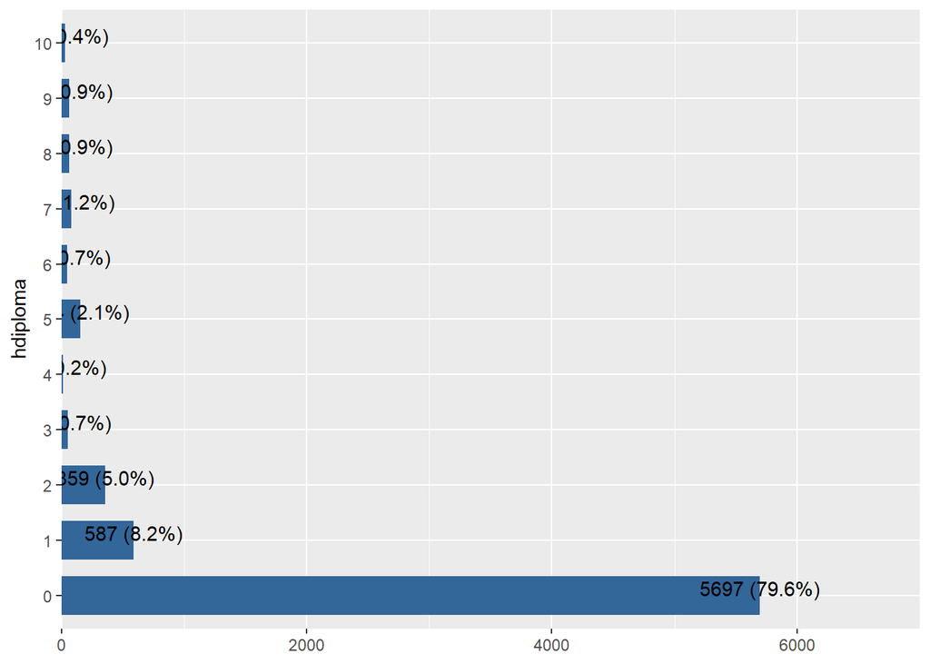

```r
wel_18 %>%
  plot_frq(coord.flip =T,hdiploma)
```

```r
#View labels
expss::val_lab(wel_21$hdiploma)
```

```
##           Aucun            cepe            bepc             cap              bt
##               0               1               2               3               4
##             bac  DEUG, DUT, BTS         Licence        Maitrise Master/DEA/DESS
##               5               6               7               8               9
##    Doctorat/Phd
##              10
```

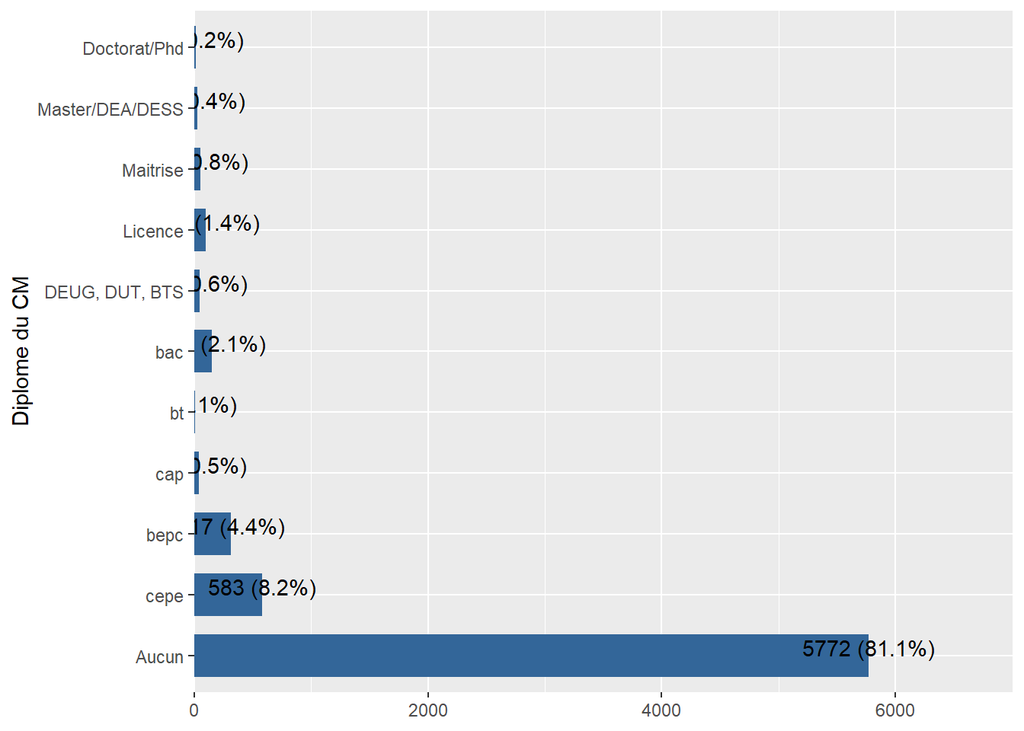

```r
wel_21 %>%
  plot_frq(coord.flip =T,hdiploma)
```

```r
labels_hdiploma_2021 <- expss::val_lab(wel_21$hdiploma)

expss::val_lab(wel_18$hdiploma) <- labels_hdiploma_2021
```

```r
# Vérification des labels
print("Labels de la variable 'hdiploma' dans wel_18 :")
```

```
## [1] "Labels de la variable 'hdiploma' dans wel_18 :"
```

```r
print(val_lab(wel_18$hdiploma))
```

```
##           Aucun            cepe            bepc             cap              bt
##               0               1               2               3               4
##             bac  DEUG, DUT, BTS         Licence        Maitrise Master/DEA/DESS
##               5               6               7               8               9
##    Doctorat/Phd
##              10
```

```r
print("Labels de la variable 'hdiploma' dans wel_21 :")
```

```
## [1] "Labels de la variable 'hdiploma' dans wel_21 :"
```

```r
print(val_lab(wel_21$hdiploma))
```

```
##           Aucun            cepe            bepc             cap              bt
##               0               1               2               3               4
##             bac  DEUG, DUT, BTS         Licence        Maitrise Master/DEA/DESS
##               5               6               7               8               9
##    Doctorat/Phd
##              10
```

```r
table(haven::as_factor(wel_18$hdiploma), useNA = "ifany")
```

```
##
##           Aucun            cepe    Doctorat/Phd            bepc             cap
##            5697             587              31             359              52
##              bt             bac  DEUG, DUT, BTS         Licence        Maitrise
##              16             154              49              83              63
## Master/DEA/DESS
##              65
```

```r
table(haven::as_factor(wel_21$hdiploma), useNA = "ifany")
```

```
##
##           Aucun            cepe            bepc             cap              bt
##            5772             583             317              39               7
##             bac  DEUG, DUT, BTS         Licence        Maitrise Master/DEA/DESS
##             150              46             101              55              32
##    Doctorat/Phd
##              18
```

- Handicap majeur (hhandig)

```r
#View labels

expss::val_lab(wel_18$hhandig)
```

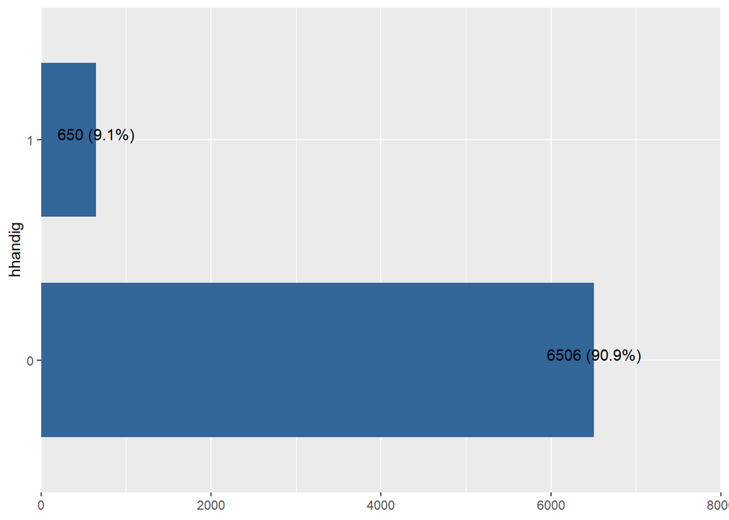

```r
wel_18 %>%
  plot_frq(coord.flip =T,hhandig)
```

```r
#View labels

expss::val_lab(wel_21$hhandig)
```

```
## Non Oui
##   0   1
```

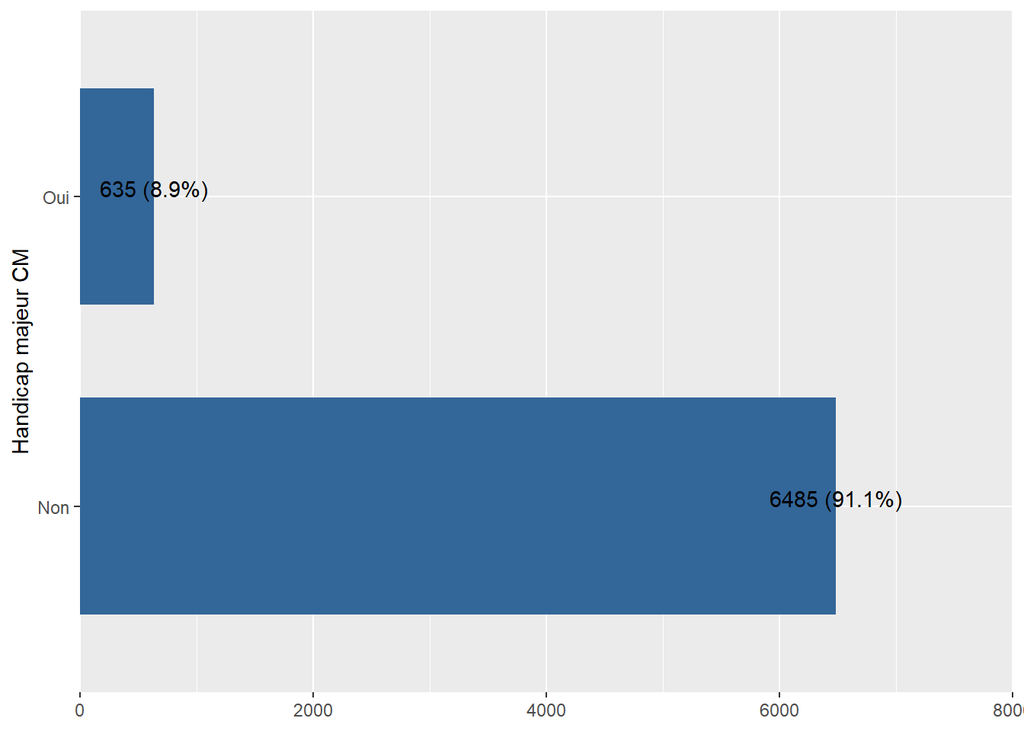

```r
wel_21 %>%
  plot_frq(coord.flip =T,hhandig)
```

```r
labels_hhandig_2021 <- expss::val_lab(wel_21$hhandig)

expss::val_lab(wel_18$hhandig) <- labels_hhandig_2021
```

```r
# Vérification des labels
print("Labels de la variable 'hhandig' dans wel_18 :")
```

```
## [1] "Labels de la variable 'hhandig' dans wel_18 :"
```

```r
print(val_lab(wel_18$hhandig))
```

```
## Non Oui
##   0   1
```

```r
print("Labels de la variable 'hhandig' dans wel_21 :")
```

```
## [1] "Labels de la variable 'hhandig' dans wel_21 :"
```

```r
print(val_lab(wel_21$hhandig))
```

```
## Non Oui
##   0   1
```

```r
table(haven::as_factor(wel_18$hhandig), useNA = "ifany")
```

```
##
##  Non  Oui
## 6506  650
```

```r
table(haven::as_factor(wel_21$hhandig), useNA = "ifany")
```

```
##
##  Non  Oui
## 6485  635
```

Convertir maintenant toutes les variables à labels en facteur pour les deux bases

```r
convert_to_factor <- function(data) {
  data %>%
    mutate(across(where(~ !is.null(expss::val_lab(.))), haven::as_factor))
}

# Appliquer la conversion sur les deux bases
wel_18 <- convert_to_factor(wel_18)
wel_21 <- convert_to_factor(wel_21)
```

Harmoniser les noms des variables dans les deux bases au cas ou il aurait des anomalies de nom.

clean_names() de janitor :Convertit tous les noms en minuscules, remplace les espaces et caractères spéciaux par des underscores (_) et supprime les accents et caractères non standards.

```r
# Nettoyage des noms + ajout des suffixes

wel_18 <- wel_18 %>%
  clean_names() %>%
  rename_with(~ paste0(., "_2018"))

wel_21 <- wel_21 %>%
  clean_names() %>%
  rename_with(~ paste0(., "_2021"))
```

```r
names(wel_18)
```

```
##  [1] "country_2018"   "year_2018"      "hhid_2018"      "grappe_2018"
##  [5] "menage_2018"    "vague_2018"     "zae_2018"       "region_2018"
##  [9] "milieu_2018"    "hhweight_2018"  "hhsize_2018"    "eqadu1_2018"
## [13] "eqadu2_2018"    "hgender_2018"   "hage_2018"      "hmstat_2018"
## [17] "hreligion_2018" "hnation_2018"   "halfab_2018"    "heduc_2018"
## [21] "hdiploma_2018"  "hhandig_2018"   "hactiv7j_2018"  "hactiv12m_2018"
## [25] "hbranch_2018"   "hsectins_2018"  "hcsp_2018"      "dali_2018"
## [29] "dnal_2018"      "dtot_2018"      "pcexp_2018"     "zzae_2018"
## [33] "zref_2018"      "def_spa_2018"   "def_temp_2018"
```

```r
names(wel_21)
```

```
##  [1] "grappe_2021"               "menage_2021"
##  [3] "country_2021"              "year_2021"
##  [5] "hhid_2021"                 "vague_2021"
##  [7] "month_2021"                "zae_2021"
##  [9] "region_2021"               "milieu_2021"
## [11] "hhweight_2021"             "hhsize_2021"
## [13] "eqadu1_2021"               "eqadu2_2021"
## [15] "hgender_2021"              "hage_2021"
## [17] "hmstat_2021"               "hreligion_2021"
## [19] "hnation_2021"              "hethnie_2021"
## [21] "halfab_2021"               "halfa2_2021"
## [23] "heduc_2021"                "hdiploma_2021"
## [25] "hhandig_2021"              "hactiv7j_2021"
## [27] "hactiv12m_2021"            "hbranch_2021"
## [29] "hsectins_2021"             "hcsp_2021"
## [31] "dali_2021"                 "dnal_2021"
## [33] "dtot_2021"                 "pcexp_2021"
## [35] "zzae_2021"                 "zref_2021"
## [37] "def_spa_2021"              "def_temp_2021"
## [39] "def_temp_prix2021m11_2021" "def_temp_cpi_2021"
## [41] "def_temp_adj_2021"         "zali0_2021"
## [43] "dtet_2021"                 "monthly_cpi_2021"
## [45] "cpi2017_2021"              "icp2017_2021"
## [47] "dollars_2021"
```

# 5 Fusion des bases

Cette section présente la méthode de fusion retenue pour combiner nos deux bases de données (2018 et 2021). Nous optons pour une approche par empilement (row-binding), qui consiste à superposer verticalement les observations.

```r
wel_fusion <- bind_rows(
  wel_18 %>% mutate(across(where(is.numeric), as.character)),
  wel_21 %>% mutate(across(where(is.numeric), as.character))
)

head(wel_fusion)
```

| country_2018 | year_2018 | hhid_2018 | grappe_2018 | menage_2018 | vague_2018 | zae_2018 | region_2018 | milieu_2018 | hhweight_2018 | hhsize_2018 | eqadu1_2018 | eqadu2_2018 | hgender_2018 | hage_2018 | hmstat_2018 | hreligion_2018 | hnation_2018 | halfab_2018 | heduc_2018 | hdiploma_2018 | hhandig_2018 | hactiv7j_2018 | hactiv12m_2018 | hbranch_2018 | hsectins_2018 | hcsp_2018 | dali_2018 | dnal_2018 | dtot_2018 | … |
| --- | --- | --- | --- | --- | --- | --- | --- | --- | --- | --- | --- | --- | --- | --- | --- | --- | --- | --- | --- | --- | --- | --- | --- | --- | --- | --- | --- | --- | --- | --- |
| SEN | 2018 | 1001 | 1 | 1 | 1 | NA | 1 | Urbain | 1749.83215332031 | 2 | 1.32000005245209 | 1.61214470863342 | Féminin | 59 | Célibataire | Musulman | Guinee | Oui | Primaire | cepe | Non | Occupe | Occupe | NA | Entreprise Privée | Ouvrier ou employé non qualifié | 1978488.125 | 13139233.1726074 | 15117721 | … |
| SEN | 2018 | 1002 | 1 | 2 | 1 | NA | 1 | Urbain | 1749.83215332031 | 2 | 1.45000004768372 | 1.61214470863342 | Masculin | 59 | Marié(e) monogame | Chrétien | Nigeria | Oui | Superieur | DEUG, DUT, BTS | Non | Occupe | Occupe | NA | Entreprise Privée | Cadre supérieur | 1886312.73730469 | 8894984.91711426 | 10781298 | … |
| SEN | 2018 | 1003 | 1 | 3 | 1 | NA | 1 | Urbain | 1749.83215332031 | 1 | 1 | 1 | Masculin | 27 | Célibataire | Chrétien | Guinee | Oui | Superieur | Doctorat/Phd | Non | Occupe | Occupe | NA | Etat/Collectivités locales | Stagiaire ou Apprenti non rénuméré | 387989.2109375 | 5055662.80078125 | 5443652 | … |
| SEN | 2018 | 2001 | 2 | 1 | 2 | NA | 1 | Urbain | 266.317016601562 | 10 | 7.66000008583069 | 5.53945875167847 | Masculin | 85 | Marié(e) monogame | Musulman | Guinee | Oui | Primaire | Aucun | Non | Inactif | Non occupe | NA | NA | NA | 6568517.93890381 | 4889539.01123047 | 11458057 | … |
| SEN | 2018 | 2002 | 2 | 2 | 2 | NA | 1 | Urbain | 266.317016601562 | 6 | 4.27999997138977 | 3.24624681472778 | Masculin | 40 | Marié(e) monogame | Musulman | Guinee | Non | Aucun | Aucun | Non | Occupe | Occupe | NA | Entreprise Privée | Ouvrier ou employé non qualifié | 2362250.44970703 | 3930703.23516846 | 6292953.5 | … |
| SEN | 2018 | 2003 | 2 | 3 | 2 | NA | 1 | Urbain | 266.317016601562 | 4 | 3.14000004529953 | 2.44471025466919 | Féminin | 68 | Veuf(ve) | Musulman | Guinee | Oui | Aucun | Aucun | Non | Inactif | Non occupe | NA | NA | NA | 458985.56817627 | 708967.668334961 | 1167953.25 | … |

```r
haven::write_dta(wel_fusion, "../Donnees/wel_fusion.dta")
```